# Pokemon Ecology

Skye Smith, Kit Eller

2024-12-07

# Pokemon Ecology

## Introduction

Our data comes from the pokemon videogames, which have been released regularly since 1996. The data itself is a collection of the statistics found within the pokedex contained in each game. Our data is not a sample, it is a complete collection of all pokedex entries. Since our data represents the entire population we are concerned with, there is no sampling bias. Our questions are for an observational study, as we are working from pre-collected data. The measurements were taken from the pokedex, which records information about the various pokemon that can be caught in the games. We do not suspect any bias in the data collected, as it is made up of all the stats for every pokemon game created since the first was made in 1996. This data is of interest to us because we want to explore the hypothetical ecology of the pokemon world.

## Data Visualization

### Pokemon Type Colors

```r
# Construct dataframe containing all colors
colors <- data.frame(
    id = c(1:18),
    color_name = factor(c("Bug", "Dark", "Dragon", "Electric", "Fairy",
                                 "Fighting", "Fire", "Flying", "Ghost", "Grass",
                                 "Ground", "Ice", "Normal", "Poison", "Psychic",
                                 "Rock", "Steel", "Water")),
    color = c("#a9b920", "#513d2f", "#755de0", "#fbb615", "#f3acf4",
                        "#80321f", "#f0400e", "#96a8f2", "#444595", "#73c238",
                        "#d0b157", "#aae9fd", "#c7bfb6", "#924493", "#ee4880",
                        "#9d873c", "#b6b3c2", "#3395f5")
)

# Function to select color of given type
color_pick <- function(type) {
    color <-
        colors |>
        filter(
            color_name == type
        ) |>
        summarize(
            color = first(color)
        )

    return(color[1, 1])
}
```

### Simpson’s Diversity Index

```r
# Accepts a vector n. n is made up of the number of individuals in each grouping (species) of the population
simpson <- function(n) {
  #creating the total population
  N = sum(n)
  #calculating simpson
  D = 1-(sum(n*(n-1))/(N*(N-1)))
  return(D)
}

#testn=c(4,5,3,6)
#simpson(testn)
```

### Shannon’s Diversity Index

```r
# Accepts a vector n. n is made up of the number of individuals in each grouping (species) of the population
shannon <- function(n) {
  #creating the total population
  N = sum(n)
  #creating proportions of each grouping
  pi = n/N
  #calculating shannon
  H = -1*sum(pi*log(pi))
  return(H)
}

#testn=c(4,5,3,6)
#shannon(testn)
```

### Pielou’s Eveness Index

```r
# Accepts a vector n. n is made up of the number of individuals in each grouping (species) of the population
pielou <- function(n) {
  #calculating richness (number of species or number of groupings)
  S = length(n)
  #calculating the shannon diversity index
  H = shannon(n)
  #calculating pielou
  J = H/log(S)
  return(J)
}

#testn=c(4,5,3,6)
#pielou(testn)
```

### Diversity and Eveness Graphs by Species

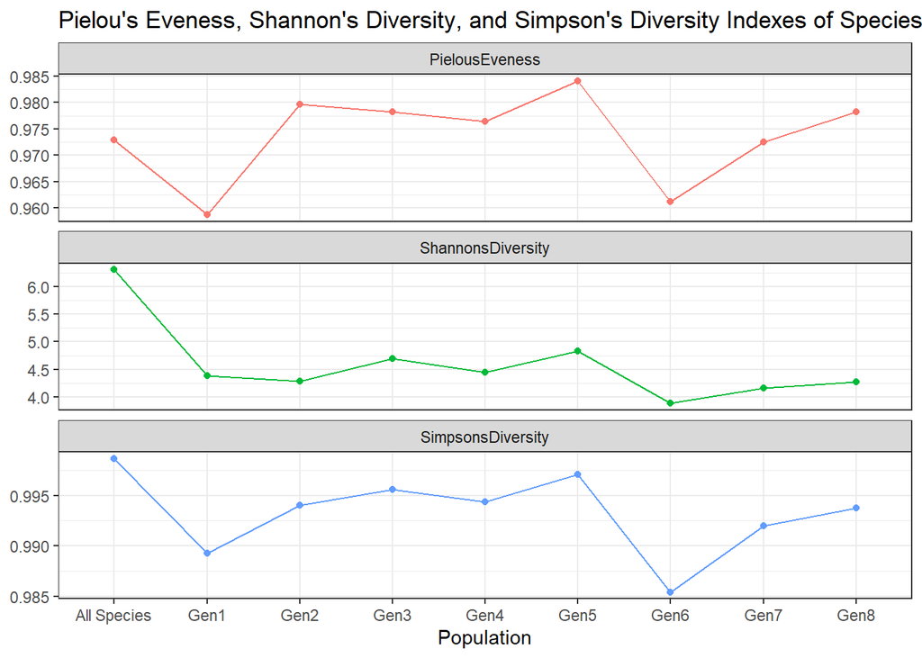

```r
#Looking at all species regardless of generation
pokemon_all_species <-
  pokemon |>
  summarize(
    .by=species,
    all_species_n=n()
  )

#Creating table to sort species by generation
pokemon_allgen_species <-
  pokemon |>
  summarize(
    .by=c(species,generation),
    gen_species_n=n()
  ) |>
  arrange(
    .by=generation
  )

# Intend to refactor and optimize for final report
gen1_species <-
  pokemon_allgen_species |>
  filter(generation==1)
gen2_species <-
  pokemon_allgen_species |>
  filter(generation==2)
gen3_species <-
  pokemon_allgen_species |>
  filter(generation==3)
gen4_species <-
  pokemon_allgen_species |>
  filter(generation==4)
gen5_species <-
  pokemon_allgen_species |>
  filter(generation==5)
gen6_species <-
  pokemon_allgen_species |>
  filter(generation==6)
gen7_species <-
  pokemon_allgen_species |>
  filter(generation==7)
gen8_species <-
  pokemon_allgen_species |>
  filter(generation==8)

pokemon_diversity_species_comparison <-
    data.frame(
      "Population"=c("All Species","Gen1","Gen2","Gen3","Gen4","Gen5","Gen6","Gen7","Gen8"),
      "SimpsonsDiversity"=c(simpson(pokemon_all_species$all_species_n),
                                                simpson(gen1_species$gen_species_n), simpson(gen2_species$gen_species_n),
                                                simpson(gen3_species$gen_species_n), simpson(gen4_species$gen_species_n),
                                                simpson(gen5_species$gen_species_n), simpson(gen6_species$gen_species_n),
                                                simpson(gen7_species$gen_species_n), simpson(gen8_species$gen_species_n)),
      "ShannonsDiversity"=c(shannon(pokemon_all_species$all_species_n),
                                                shannon(gen1_species$gen_species_n), shannon(gen2_species$gen_species_n),
                                                shannon(gen3_species$gen_species_n), shannon(gen4_species$gen_species_n),
                                                shannon(gen5_species$gen_species_n), shannon(gen6_species$gen_species_n),
                                                shannon(gen7_species$gen_species_n), shannon(gen8_species$gen_species_n)),
      "PielousEveness"=c(pielou(pokemon_all_species$all_species_n),
                                         pielou(gen1_species$gen_species_n), pielou(gen2_species$gen_species_n),
                                         pielou(gen3_species$gen_species_n), pielou(gen4_species$gen_species_n),
                                         pielou(gen5_species$gen_species_n), pielou(gen6_species$gen_species_n),
                                         pielou(gen7_species$gen_species_n), pielou(gen8_species$gen_species_n))
  )

# Graph resulting data
pokemon_diversity_species_comparison |>
    pivot_longer(
        -Population
    ) |>
    ggplot(
        mapping = aes(x = Population, y = value, group = name, color=name)
    ) +
    geom_line() +
  geom_point() +
  facet_wrap(~name,ncol=1,scales="free_y") +
  labs(
    y=NULL,
    color=NULL,
    title="Pielou's Eveness, Shannon's Diversity, and Simpson's Diversity Indexes of Species"
  ) +
  theme(
    legend.position="none"
  )
```

The above graph is simply showing a comparison of each generation’s Pielou’s Eveness, Shannon’s Diversity, and Simpson’s Diversity Indexes according to species. “All Species” refers to all species in the pokedex dataset regardless of generation, after which each generation’s species indexes are shown. Pielou’s Eveness index remains quite similar across all generations, though it dips slightly (by around 0.01) at generations 1 and 6. Simpson’s diversity and Shannon’s diversity indexes generally follow this same trend, and diversity is notably lowest in generation 6, suggesting that pokemon from gen 6 represent a less diverse ecological community.

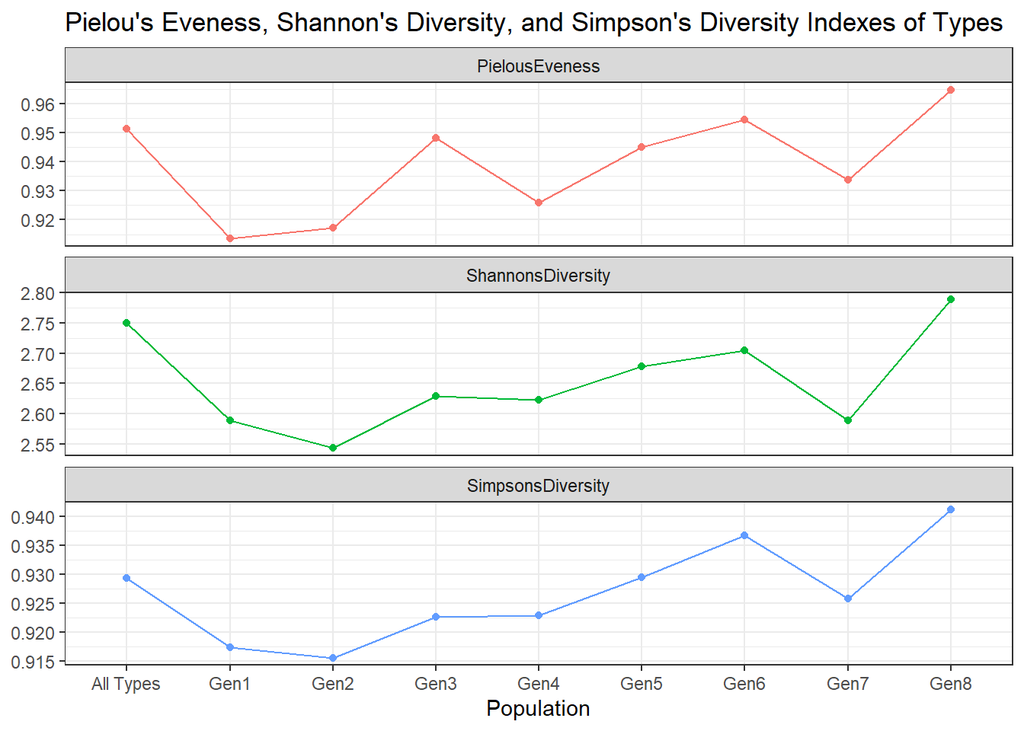

```r
#Looking at all species regardless of generation
pokemon_all_type <-
  pokemon |>
  summarize(
    .by=type_1,
    all_type_n=n()
  )

#Creating table to sort species by generation
pokemon_allgen_type <-
  pokemon |>
  summarize(
    .by=c(type_1,generation),
    gen_type_n=n()
  ) |>
  arrange(
    .by=generation
  )

# Intend to refactor and optimize for final report
gen1_types <-
  pokemon_allgen_type |>
  filter(generation==1)
gen2_types <-
  pokemon_allgen_type |>
  filter(generation==2)
gen3_types <-
  pokemon_allgen_type |>
  filter(generation==3)
gen4_types <-
  pokemon_allgen_type |>
  filter(generation==4)
gen5_types <-
  pokemon_allgen_type |>
  filter(generation==5)
gen6_types <-
  pokemon_allgen_type |>
  filter(generation==6)
gen7_types <-
  pokemon_allgen_type |>
  filter(generation==7)
gen8_types <-
  pokemon_allgen_type |>
  filter(generation==8)

pokemon_diversity_types_comparison <-
    data.frame(
      "Population"=c("All Types","Gen1","Gen2","Gen3","Gen4","Gen5","Gen6","Gen7","Gen8"),
      "SimpsonsDiversity"=c(simpson(pokemon_all_type$all_type_n),
                                                simpson(gen1_types$gen_type_n), simpson(gen2_types$gen_type_n),
                                                simpson(gen3_types$gen_type_n), simpson(gen4_types$gen_type_n),
                                                simpson(gen5_types$gen_type_n), simpson(gen6_types$gen_type_n),
                                                simpson(gen7_types$gen_type_n), simpson(gen8_types$gen_type_n)),
      "ShannonsDiversity"=c(shannon(pokemon_all_type$all_type_n),
                                                shannon(gen1_types$gen_type_n), shannon(gen2_types$gen_type_n),
                                                shannon(gen3_types$gen_type_n), shannon(gen4_types$gen_type_n),
                                                shannon(gen5_types$gen_type_n), shannon(gen6_types$gen_type_n),
                                                shannon(gen7_types$gen_type_n), shannon(gen8_types$gen_type_n)),
      "PielousEveness"=c(pielou(pokemon_all_type$all_type_n),
                                         pielou(gen1_types$gen_type_n), pielou(gen2_types$gen_type_n),
                                         pielou(gen3_types$gen_type_n), pielou(gen4_types$gen_type_n),
                                         pielou(gen5_types$gen_type_n), pielou(gen6_types$gen_type_n),
                                         pielou(gen7_types$gen_type_n), pielou(gen8_types$gen_type_n))
  )

# Graph resulting data
pokemon_diversity_types_comparison |>
    pivot_longer(
        -Population
    ) |>
    ggplot(
        mapping = aes(x = Population, y = value, group = name, color=name)
    ) +
    geom_line() +
  geom_point() +
  facet_wrap(~name,ncol=1,scales="free_y") +
  labs(
    y=NULL,
    color=NULL,
    title="Pielou's Eveness, Shannon's Diversity, and Simpson's Diversity Indexes of Types"
  ) +
  theme(
    legend.position="none"
  )
```

The above graph shows a comparison of each generation’s Pielou’s Eveness, Shannon’s Diversity, and Simpson’s Diversity Indexes according to type. “All Types” refers to all types in the pokedex dataset regardless of generation, after which each generation’s types indexes are shown. While at the scale of the data, there is less variation than compared to the diversity by species; there are still some trends in the data. Generations 1 and 2 tend to have less diversity and eveness of pokemon types tgan compared to the rest, until a slight spike in generation 3. At this point, the both eveness and diversity tends to increase until it peaks at gen 6. At this point, there is a sudden decrease at gen 7, until all metrics peak at their highest eveness and diversity scores at generation 8.

## Proportion of Multi-type Pokemon

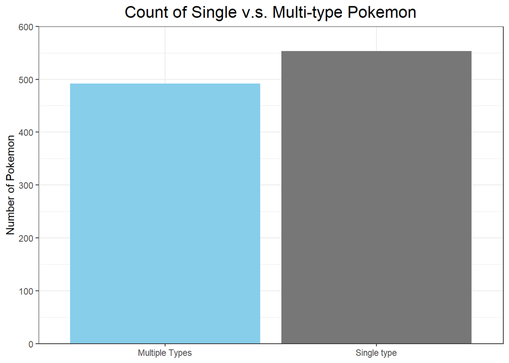

```r
pokemon |>
    summarize(
        num_types = if_else(is.na(type_2), "Multiple Types", "Single type")
    ) |>
    ggplot(
        mapping = aes(x = num_types)
    ) +
    geom_bar(
        fill = c("skyblue", "#777777")
    ) +
    scale_y_continuous(
        expand = c(0,0),
        limits = c(0, 600)
    ) +
    labs(
        title = "Count of Single v.s. Multi-type Pokemon",
        y = "Number of Pokemon"
    ) +
    theme(
        plot.title = element_text(size = 16, hjust = 0.5),
        axis.title.x = element_blank()
    )
```

## Average Power by Type

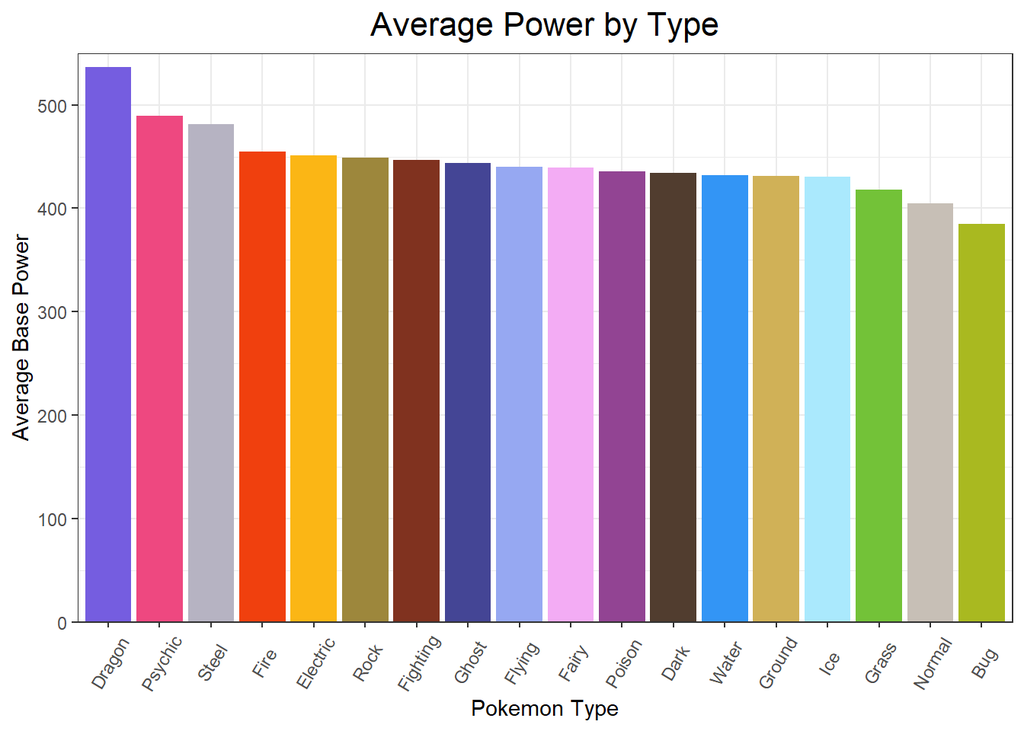

```r
pokemon |>
    summarize(
        .by = type_1,
        avg_power = mean(total_points)
    ) |>
    arrange(
        desc(avg_power)
    ) |>
    ggplot(
        mapping = aes(x = reorder(type_1, avg_power, decreasing = TRUE), y = avg_power)
    ) +
    geom_col(
        fill = c(color_pick("Dragon"), color_pick("Psychic"), color_pick("Steel"),
                         color_pick("Fire"), color_pick("Electric"), color_pick("Rock"),
                         color_pick("Fighting"), color_pick("Ghost"), color_pick("Flying"),
                         color_pick("Fairy"), color_pick("Poison"), color_pick("Dark"),
                         color_pick("Water"), color_pick("Ground"), color_pick("Ice"),
                         color_pick("Grass"), color_pick("Normal"), color_pick("Bug"))
    ) +
    scale_y_continuous(
        expand = c(0,0),
        limits = c(0, 550)
    ) +
    labs(
        title = "Average Power by Type",
        x = "Pokemon Type",
        y = "Average Base Power"
    ) +
    theme(
        plot.title = element_text(size = 16, hjust = 0.5),
        axis.text.x = element_text(angle = 59, vjust = 0.5)
    )
```

The graph above displays the average base power of pokemon with respect to their primary type. From this graph we can determine a few interesting relationships between type and strength. For instance, there appears to be a large number of types which, on average, exhibit similar strength (on the graph, roughly fire through Ice). However, there are three types on the high and low end which exhibit a larger difference in strength from their peers. On the high end, Dragon, Psychic and Steel are all notably stronger, and on the low end, Grass, Normal and Bug type pokemon are weaker on average. We believe that this data implies a dramatic difference between the average conditions which the pokemon of various types are subject to in their natural habitats. For instance, Draconic pokemon may tend to live in much more hostile environmentss than the average normal type pokemon, and thus, Dragon types have developed greater resilience.

## Machine Learning Methods

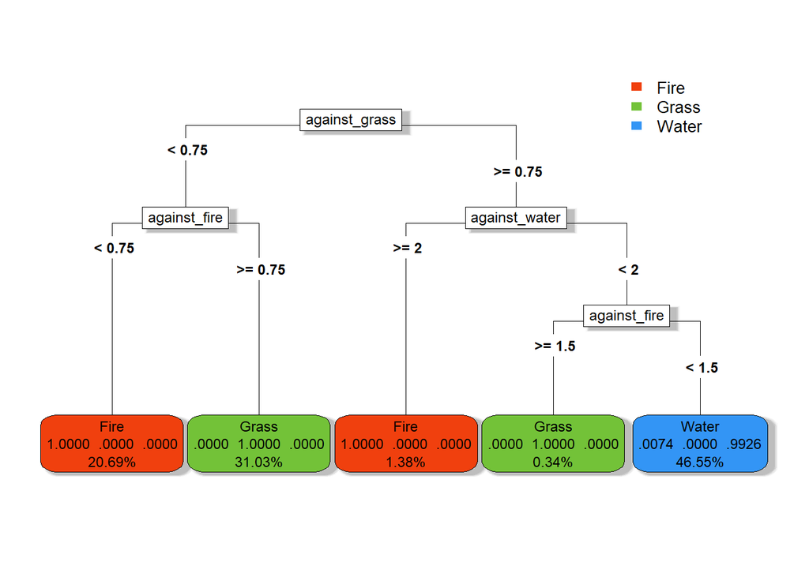

```r
RNGversion("4.1.0")
set.seed(2870)

# Creating new column that has four types: fire, water, grass, and "other" for all other types. If this dataset had data available on the starter pokemon, this is what this tree would have been used for, but for now it will be used to predict one of those four types based off of the pokemon's weaknesses.

#pokemon_type_trim <-
#  pokemon |>
#  mutate(
#    type_1_trim = if_else(
#      type_1=="Grass" | type_1=="Fire" | type_1=="Water",
#      true=type_1, false="Other"
#    )
#  )

pokemon_type_trim2 <-
  pokemon |>
  mutate(
    type_1_trim = if_else(
      type_1=="Grass" | type_1=="Fire" | type_1=="Water",
      true=type_1, false="Other"
    )
  ) |>
  filter(
    type_1_trim != "Other"
  )

# Create the full classification tree below
poke_tree_full <-
    rpart(
        formula = type_1_trim ~
          against_normal +
          against_fire +
          against_water +
          against_electric +
          against_grass +
          against_ice +
          against_fight +
          against_poison +
          against_ground +
          against_flying +
          against_psychic +
          against_bug +
          against_rock +
          against_ghost +
          against_dragon +
          against_dark +
          against_steel +
          against_fairy,
        data = pokemon_type_trim2,
        method = "class",
        parms = list(split = "information"),
        minsplit = 2,
        minbucket = 1,
        model = TRUE,
        cp = -1
    )

poke_tree_full$cptable |>
  data.frame() |>
    slice_min(
        xerror,
        n = 1
    ) |>
    mutate(
        xcutoff = xerror + xstd
    ) |>
    pull(xcutoff) ->
    x_cutoff

poke_tree_full$cptable |>
    data.frame() |>
    filter(
        xerror < x_cutoff
    ) |>
    slice(1) |>
    pull(CP) ->
    cp_cutoff

prune(
    tree = poke_tree_full,
    cp = cp_cutoff
) ->
    poke_tree_pruned

rpart.plot(
  poke_tree_pruned,
  type = 5,
  digits = 4,
  fallen.leaves = TRUE,
  box.palette = list("#f0400e","#73c238","#3395f5"),
  shadow.col = "gray"
)
```

```r
caret::varImp(poke_tree_pruned) |>
  arrange(desc(Overall))
```

```
##                    Overall
## against_fire     264.88286
## against_water    254.94876
## against_ice      227.90026
## against_steel    219.61118
## against_grass    192.51933
## against_bug       96.92029
## against_fairy     18.85534
## against_ground    11.71860
## against_normal     0.00000
## against_electric   0.00000
## against_fight      0.00000
## against_poison     0.00000
## against_flying     0.00000
## against_psychic    0.00000
## against_rock       0.00000
## against_ghost      0.00000
## against_dragon     0.00000
## against_dark       0.00000
```

In this classification tree, we predicted the primary type (type_1) of a pokemon based off of the types it was weak to. For the purposes of making a readable tree, we filtered out all types that were not fire, grass, or water. If this data had included information about starter pokemon, this might have been a good graph to use to predict whether a starter pokemon was a Fire, Grass, or Water type based off of its weaknesses, but as it exists right now, this includes all pokemon of those types rather than just the starters. This tree can be used to make predictions about a pokemon’s type based off of its weaknesses.

# KNN Predicting Pokemon Base Experience Value

For this model we predicted the base experience value of Pokemon from the base stat values (hp, defense, etc.).

```r
set.seed(2870)
k <- 5:100

normalize <- function(x) {
  return((x - min(x)) / (max(x) - min(x)))
}

xp_vals <-
  pokemon |>
  select(
    base_experience,
    hp:speed
  ) |>
  drop_na() |>
  pull(base_experience)

poke_norm <-
  pokemon |>
  select(
    base_experience,
    hp:speed
  ) |>
  drop_na() |>
  select(
    -base_experience
  ) |>
  mutate(
    across(
      .fns = normalize
    )
  )
```

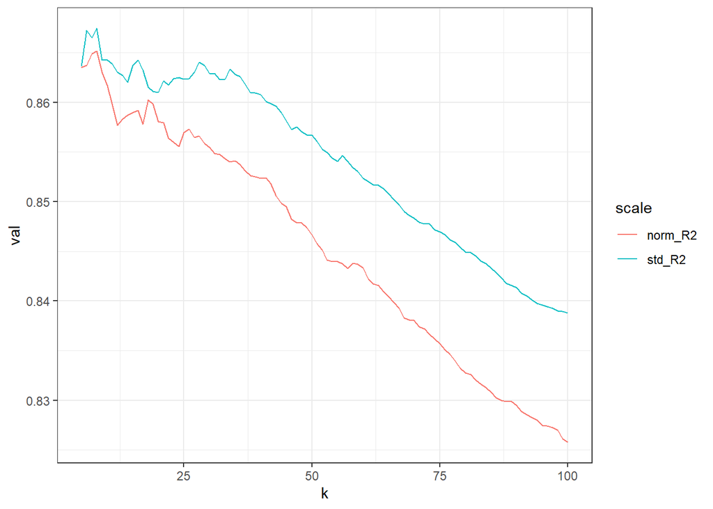

```r
standardize <- function(x) {
  return((x - mean(x)) / sd(x))
}

poke_std <-
  pokemon |>
  select(
    base_experience,
    hp:speed
  ) |>
  drop_na() |>
  select(
    -base_experience
  ) |>
  mutate(
    across(
      .fns = standardize
    )
  )

stats_df <-
  tibble(
    k = k,
    norm_R2 = rep(-1, length(k)),
    std_R2 = rep(-1, length(k))
  )

# Write your code below
for (i in k) {
  xp_norm_knn <-
    knn.reg(
      train = poke_norm,
      y = xp_vals,
      k = i
    )

  xp_std_knn <-
    knn.reg(
      train = poke_std,
      y = xp_vals,
      k = i
    )

  stats_df[i - k[[1]] + 1, "norm_R2"] <- xp_norm_knn$R2Pred
  stats_df[i - k[[1]] + 1, "std_R2"] <- xp_std_knn$R2Pred
}

stats_df |>
  pivot_longer(
    cols = norm_R2:std_R2,
    names_to = "scale",
    values_to = "val"
  ) |>
  ggplot(
    mapping = aes(x = k, y = val, color = scale)
  ) +
  geom_line()
```

Due to the algorithms nature as a KNN, a lazy learner, we cannot analyze how the different statistics affected the predictions, but were able to achieve an R2 value of ~0.87, which suggests that there is a fairly strong relationship between the provided stats and base_experience.

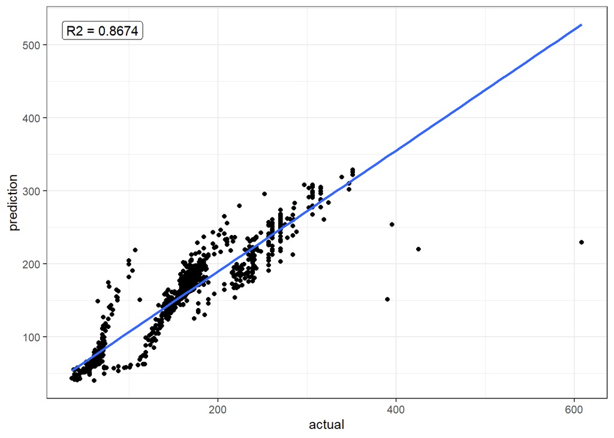

```r
best_knn <-
  knn.reg(
    train = poke_std,
    y = xp_vals,
    k = 8
  )

y_hat = best_knn$pred

R2 = 1 - (
  sum((xp_vals - y_hat)^2) /
    sum((xp_vals - mean(xp_vals))^2)
)

tibble(
  prediction = y_hat,
  actual = xp_vals
) |>
  ggplot(
    mapping = aes(y = prediction, x = actual)
  ) +
  geom_point() +
  geom_smooth(
    method = "lm",
    se = FALSE
  ) +
  geom_label(
    label = paste("R2 =", round(R2, 4)),
    x = 70,
    y = 520
  )
```

# Linear Model Predicting Pokemon Weight

For this model, we predicted the weight of Pokemon given their height, hp and types. Our model is moderately effective, achieving an R2 value of 0.64. However, To achieve this, we required adding both types, which are categorical values with 18 options, causing our number of predictors to be largely inflated. There does appear to be a correlation between weight and our provided explanatory variables, and that our model is significantly better than random guesses. This makes sense as it is likely a tall steel-type Pokemon would be significantly heavier than a short flying-type. However, since this correlation appears to be weak, we recommend that, should predictions of this nature be required in the future, other variables are investigated, perhaps adding length, or volume to the dataset would significantly improve results.

```r
weight_lm <-
    pokemon |>
    lm(
        formula = weight_kg ~ height_m + hp + type_1 + type_2
    )

weight_lm
```

```
##
## Call:
## lm(formula = weight_kg ~ height_m + hp + type_1 + type_2, data = pokemon)
##
## Coefficients:
##    (Intercept)        height_m              hp      type_1Dark    type_1Dragon
##        -87.487          53.381           1.151          -9.703         -14.653
## type_1Electric     type_1Fairy  type_1Fighting      type_1Fire    type_1Flying
##        -13.161          30.497          14.145           7.672         -61.013
##    type_1Ghost     type_1Grass    type_1Ground       type_1Ice    type_1Normal
##         23.080         -15.521          23.978         -11.631          -4.651
##   type_1Poison   type_1Psychic      type_1Rock     type_1Steel     type_1Water
##        -38.788           1.431          36.339         116.381         -21.149
##     type_2Dark    type_2Dragon  type_2Electric     type_2Fairy  type_2Fighting
##         12.060          41.782          20.505         -24.311          -1.767
##     type_2Fire    type_2Flying     type_2Ghost     type_2Grass    type_2Ground
##         45.573         -19.081         -21.489         -20.117          24.731
##      type_2Ice    type_2Normal    type_2Poison   type_2Psychic      type_2Rock
##         65.905           3.966          -3.052          19.254          32.307
##    type_2Steel     type_2Water
##         76.673          15.541
```

```r
bind_rows(
  .id = "model",
  "weight_lm" = glance(weight_lm),

) |>
  dplyr::select(model, n_predictors = df, r.squared, sigma) |>
  mutate(r.squared = round(r.squared, 3),
         sigma = round(sigma, 0)) |>
  gt::gt()
```

| model | n_predictors | r.squared | sigma |
| --- | --- | --- | --- |
| weight_lm | 36 | 0.636 | 90 |

## Conclusions

While there are some slight differences in the diversity of species across generations, generally, the diversity and eveness of species and types of each generation are mostly similar to one another. The number of single-type versus multi-type pokemon are not significantly different from one another, indicating that the two populations are relatively similar to one another. In comparing each types average power, it was found that Dragon-type pokemon tend to be the most powerful, while Bug-type pokemon tend to be the weakest. In addition, using our models, both basic and less obvious information on a pokemon can be predicted from its statistics. Pokemon type could be predicted from its weaknesses, its base experience can be predicted from its base stat values such as HP and defense, and its weight can be predicted from its height, hp, and type.

## Limitations / Reccomendations

We believe that the breadth of our conclusions was limited by the nature of our available data. While we were able to make conclusions relevant to the ecological diversity indices we employed, the implications of our other efforts would best serve as hypotheses to be tested with further study. For instance, the trends in average power we derived are interesting, but could be very different if we had access to information about the population size of each Pokemon species. Without this information, we can give little confidence that the trends observed are representative of the actual populations of Pokemon in the wider world.